# R Notebook

#2

Often d = 1 works well, in which case each tree is a stump, consisting of a single split. In this case, the boosted stump ensemble is fitting an additive model, since each term involves only a single variable.

#4

```
               x1 < 1
                -----
               |     |
            x2 < 1   5
             -----
            |     |
         x1 < 0   15
         -----
        |     |
        3  x2 < 0
            -----
           |     |
          10     0
```

[output not shown]

Vote approach: Red > 0.5, green < 0.49

Red = 6 Green = 4 Final classification is Red

#3

#8 a)

```r
library (ISLR2)
attach (Carseats)
Carseats$Sales <- as.numeric(Carseats$Sales)

set.seed(1)
train <- sample(1:nrow(Carseats), size = round(0.7 * nrow(Carseats)), replace = FALSE)
trainSet <- Carseats[train, ]
testSet <- Carseats[-train, ]
```

2. Results: seems like showing sales towards left sides of the tree gives off more identification in the different variable sets.

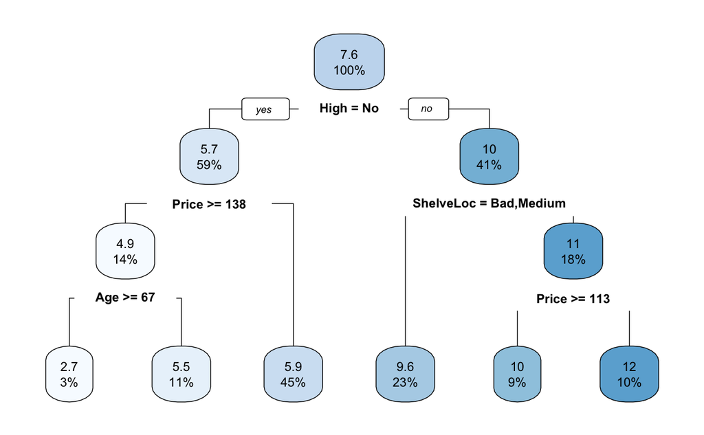

```r
library(rpart)
library(rpart.plot)

R.tree <- rpart(Sales ~ ., data = trainSet )
rpart.plot(R.tree)
```

```r
summary(R.tree)
```

```
Call:
rpart(formula = Sales ~ ., data = trainSet)
  n= 280

          CP nsplit rel error    xerror
1 0.65262286      0 1.0000000 1.0056376
2 0.03021833      1 0.3473771 0.3517364
3 0.02602682      2 0.3171588 0.3575863
4 0.01917644      3 0.2911320 0.3417885
5 0.01000000      5 0.2527791 0.3102831
        xstd
1 0.07917566
2 0.03093362
3 0.03233121
4 0.02998168
5 0.02415691

Variable importance
       High   ShelveLoc       Price
         50          17          14
        Age Advertising   CompPrice
          9           6           3
  Education      Income
          1           1

Node number 1: 280 observations,    complexity param=0.6526229
  mean=7.596607, MSE=8.056274
  left son=2 (164 obs) right son=3 (116 obs)
  Primary splits:
      High      splits as  RL,        improve=0.65262290, (0 missing)
      High.1    splits as  RL,        improve=0.65262290, (0 missing)
      ShelveLoc splits as  LRL,       improve=0.25535320, (0 missing)
      Price     < 89.5  to the right, improve=0.17397250, (0 missing)
      Age       < 61.5  to the right, improve=0.08806247, (0 missing)
  Surrogate splits:
      ShelveLoc   splits as  LRL,       agree=0.707, adj=0.293, (0 split)
      Price       < 91.5  to the right, agree=0.671, adj=0.207, (0 split)
      Age         < 50.5  to the right, agree=0.639, adj=0.129, (0 split)
      Advertising < 8.5   to the left,  agree=0.636, adj=0.121, (0 split)
      CompPrice   < 94.5  to the right, agree=0.596, adj=0.026, (0 split)
```

[output cut: 61 more lines]

```
      Income      < 41.5  to the right, agree=0.608, adj=0.167, (0 split)
      Age         < 44.5  to the left,  agree=0.608, adj=0.167, (0 split)
      Advertising < 21.5  to the right, agree=0.569, adj=0.083, (0 split)

Node number 8: 9 observations
  mean=2.733333, MSE=2.6182

Node number 9: 30 observations
  mean=5.491, MSE=2.217462

Node number 14: 24 observations
  mean=10.05042, MSE=1.666762

Node number 15: 27 observations
  mean=12.2, MSE=2.35423
```

```r
#MSE Test
tree.pred <- predict(R.tree, data = testSet)
mean((testSet$Sales - tree.pred)^2)
```

```
[1] 13.49049
```

```r
cv <- cv.tree(R.tree)
```

```
Error in cv.tree(R.tree) : not legitimate tree
```

#10 a)

```r
data("Hitters")
Hitters <- na.omit(Hitters)
Hitters$Salary <- log(Hitters$Salary)
```

```r
train <- Hitters[1:200, ]
test <- Hitters[201:nrow(Hitters), ]
```

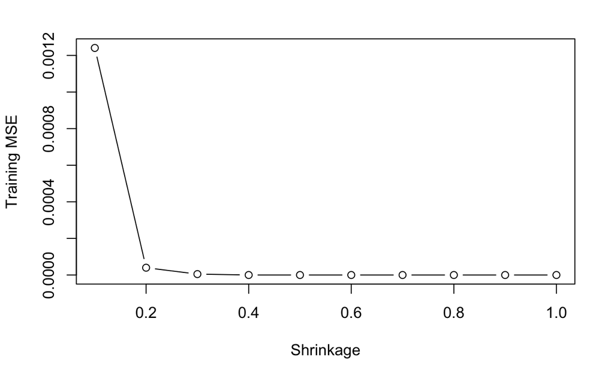

```r
library(gbm)
shrinkage_vals <- seq(0.1, 1, by = 0.1)
train_mse <- rep(NA, length(shrinkage_vals))

for (i in seq_along(shrinkage_vals)) {
  boost_mod <- gbm(Salary ~ ., data = train, distribution = "gaussian",
                   n.trees = 1000, shrinkage = shrinkage_vals[i], interaction.depth = 4)
  train_pred <- predict(boost_mod, train, n.trees = 1000)
  train_mse[i] <- mean((train_pred - train$Salary)^2)
}

plot(shrinkage_vals, train_mse, type = "b", xlab = "Shrinkage", ylab = "Training MSE")
```

7. #4 Its preferably over a classification tree because of interchangeability, flexibility, and for better predictions.

Interchangeability: Regression trees provide easier to explain compared to classification trees when it comes to many predictors and can be visualized with a split based system so its easier to understand the importance of certain predictors. Flexibility: Regression trees are both quantitative and qualitative predictors and a classification tree can only handle qualitatives predictors. Being able to have quantitative predictors gives us more information to work with in the tree and improve the model’s accuracy. Better predictions: Regression trees can be used for binary classification by setting a theshold on the predicted values, leading to better predictions than a classification tree since the tree captures more relationships for between predictors and responses.

#5 a)

```r
df.train <- read.csv("HW7train.csv", header = TRUE)
set.seed(1)
train <- sample(nrow(df.train), 900)
trainSet <- df.train[train, ]
testSet <- df.train[-train, ]
```

```r
library(randomForest)

rf <- randomForest(y ~ ., data = trainSet, importance = TRUE)
par(mfrow=c(3,1))
plot(rf$importance[,1],type="b",axes=F,ann=F,ylim=c(0,max(rf$importance[,1])+1))
axis(1,at=1:10,lab=names(df.train)[-1])
```

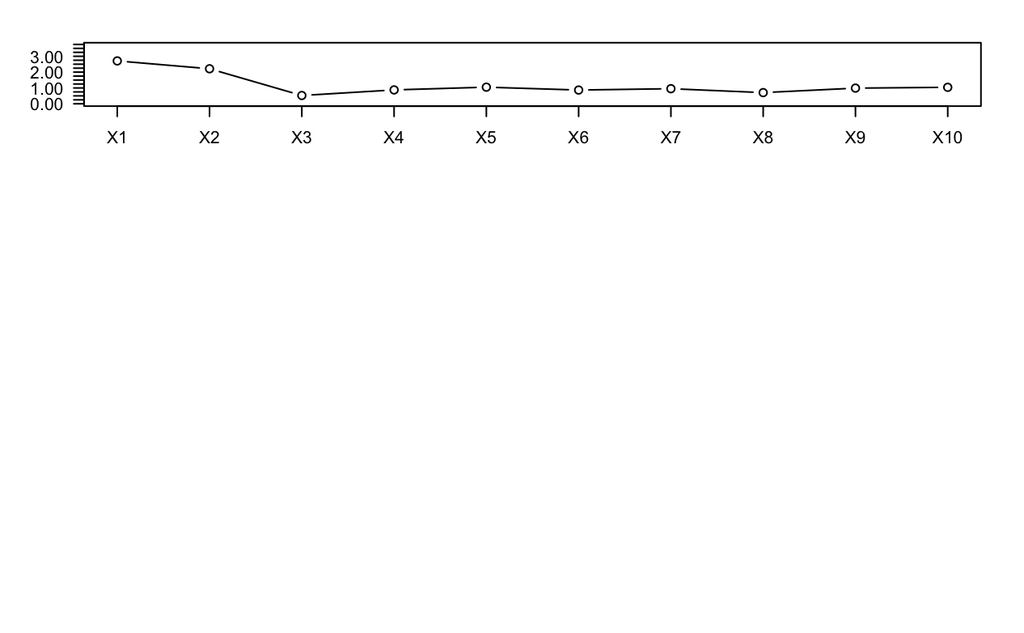

```r
axis(2,at=seq(0,max(rf$importance)+1,0.25),las=1)
box()
```

```r
NA
NA
```

```r
mse.perm <- rep(NA, 10)
for (i in 1:10) {
  perm.testSet <- testSet
  perm.testSet[, i] <- sample(testSet[, i])
  perm.pred <- predict(rf, newdata = perm.testSet)
  mse.perm[i] <- mean((testSet$y - perm.pred)^2)
}

plot(mse.perm,type="b",axes=F,ann=F,ylim=c(0,max(mse.perm)+1))
axis(1,at=1:10,lab=names(df.train)[-1])
```

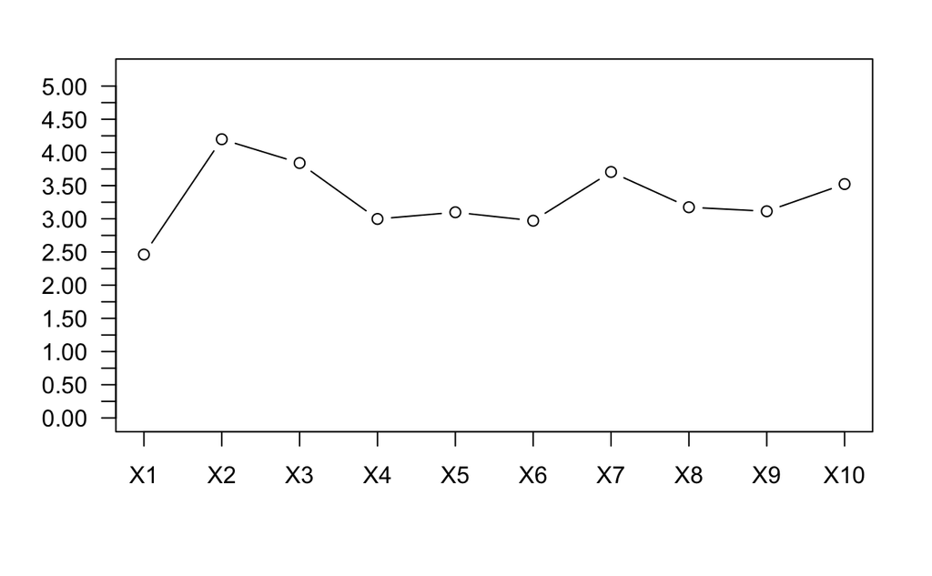

```r
axis(2,at=seq(0,max(mse.perm)+1,0.25),las=1)
box()
```

```r
mse.loo <- rep(NA, 10)
for (i in 1:10) {
  loo.trainSet <- trainSet[, i]
  loo.testSet <- testSet[, i]
  loo.rf <- randomForest(y ~ ., data = loo.trainSet, importance = TRUE)
  loo.pred <- predict(loo.rf, newdata = loo.testSet)
  mse.loo[i] <- mean((testSet$y - loo.pred)^2)
}
```

```
Error in model.frame.default(formula = y ~ ., data = loo.trainSet, na.action = function (object,  :
  'data' must be a data.frame, environment, or list
```

5. The difference might be caused by the high correlations between the predictors or have multicollinearity between the predictors.

#6 a)

```r
set.seed(1)
n <- 100
p <- 10
sigma <- 1
X <- matrix(rnorm(n*p), n, p)
epsilon <- rnorm(n, 0, sigma)
Y <- rowSums(X) + epsilon
trainSet <- data.frame(Y, X)
```

```r
set.seed(1)
n.test <- 10000
x.test <- matrix(rnorm(n.test*p), n.test, p)
ep.test <- rnorm(n.test, 0, sigma)
y.test <- rowSums(x.test) + ep.test
test.set <- data.frame(y.test, x.test)
```

```r
set.seed(1)

#bagging
bagging <- randomForest(Y ~ ., data = trainSet, mtry = p, importance = TRUE)
pred_bag <- predict(bagging, newdata = testSet)
Err_bag <- mean((y.test - pred_bag)^2)

#random forest
rf <- randomForest(Y ~ ., data = trainSet, mtry = 3, importance = TRUE)
pred.rf <- predict(rf, newdata = testSet)
Err_rf <- mean((y.test - pred.rf)^2)
```